# Concurso Pump It

by [Juan Manuel Ortiz](https://www.linkedin.com/in/juan-manuel-ortiz-10956a80/)

5/7/2020

La finalidad de este ejercicio consiste en tratar un dataset mediante distintas técnicas y procesos para averiguar el estado de unos pozos de agua, en función de distintas variables.

En mi caso obtuve varios resultados utilizando XGB el mayor fué 0.7569, pero a posteriori utilicé RANGER y el resultado fué mejorado a 0.81.

Este documento, está en un principio enfocado al resultado conseguido en XGB, pero al final hay un apartado donde se añade lo realizado para obtener el resultado mediante RANGER.

Sin duda parece que en este caso, RANGER funciona mejor que XGB.

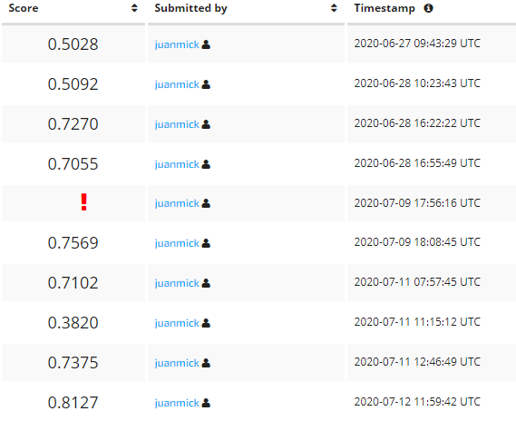

Resultados del concurso

A continuación me dispongo a presentar el código y el tratamiento que he realizado al dataset. En cada sección pondré tambien las distintas alternativas e intentos que he realizado para comprobar si mejoraba o no el resultado.

```r
# Establezco la ruta por defecto

setwd("C:/Users/juanm/Documents/Pump it up")
```

## 1. Carga de Librerias

Cargamos las distintas librerias que nos van a permitir realizar las distintas operaciones con los datos.

```r
#Cargamos las diferentes librerias que necesitaremos para el ejercicio

rm(list = ls())

library(caret)           # Equivalent to scikit-learn
library(ggplot2)         # Graphics
library(dplyr)           # Manipulation
library(data.table)      # Manipulation
library(scales)          # To scale data
library(stringi)         # Strings manipulation
library(stringr)         # Strings manipulation
library(dataPreparation) # Minipulation
library(knitr)           # RMarkdown
library(kableExtra)      # Tables formating
library(ggpubr)          # Charts elaborated
library(tictoc)          # Measure time
library(ggeasy)          # Graphics ggplot easy
library(lubridate)       # Dates Manipulation
library(inspectdf)       # Easy EDA
library(funModeling)
library(fastDummies)
library(e1071) # caret lo utiliza para la confusionmatrix
library(MLmetrics)
library(ranger)
library(xgboost)
library(tidyverse)
library(CHAID)
library(RANN)
library(skimr)
library(DataExplorer)
library(ggcorrplot)
```

## 2. Carga de datos

Los archivos originales han sido renombrados para una mayor facilidad a la hora de localizarlos y utilizarlos.

Procedo a cargar los datos y unir la variable objetivo con el dataset de entrenamiento

```r
#Cargamos el dataset de entrenamiento

datostrain <- fread( file = 'Trainingsetvalues.csv', nThread = 2)

#Cargamos las etiquetas

target <- fread( file = 'Trainingsetlabels.csv', nThread = 2)

#Unir etiqueta

datostrain <- merge(x = datostrain, y = target, by = "id") #inner join

#Cargamos dataset de test

datostest <- fread( file = 'Testsetvalues.csv', nThread = 2)
```

Se realiza una limpieza básica y mínima, para facilitar algunas operaciones del dataset

```r
# Limpieza básica

# Este valor es el mismo siempre por lo que no aporta información, lo eliminamos

datostrain$recorded_by <- NULL
datostest$recorded_by <- NULL

# La ID es distinta para cada registro, por lo que no debe aportar información, se elimina
datostrain$id <- NULL

# Salvamos la ID de los datos de test para luego incluirla en el fichero final
resultado <- select(datostest, id)
datostest$id <- NULL

# Convertimos a factor la variable objetivo

datostrain$status_group <- as.factor(datostrain$status_group) #convierto a factor

# Creamos la variable objetivo en el dataset de test, necesario para XGB

status_group=vector(mode='numeric', length=14850)
datostest$status_group <- status_group

#Convierto a fecha
datostrain$fe_fecha <- ymd(datostrain$date_recorded)
datostest$fe_fecha <- ymd(datostest$date_recorded)
datostrain$date_recorded <- NULL  #elimino columna antigua de fecha
datostest$date_recorded <- NULL   #elimino columna antigua de fecha

# Transformamos la fecha a otras variables
datostrain$fe_anio    <- year(datostrain$fe_fecha)
datostrain$fe_mes     <- month(datostrain$fe_fecha)
datostrain$fe_dianum  <- day(datostrain$fe_fecha)
datostrain$fe_diasem  <- wday(datostrain$fe_fecha, label = TRUE, abbr = TRUE)

datostest$fe_anio    <- year(datostest$fe_fecha)
datostest$fe_mes     <- month(datostest$fe_fecha)
datostest$fe_dianum  <- day(datostest$fe_fecha)
datostest$fe_diasem  <- wday(datostest$fe_fecha, label = TRUE, abbr = TRUE)

#LONGITUD Y LATITUD DEJAR Y CREAR NUEVA VARIABLE

datostrain$fe_lonlat  <- sqrt(datostrain$longitude^2 + datostrain$latitude^2)
datostest$fe_lonlat  <- sqrt(datostest$longitude^2 + datostest$latitude^2)
```

## 3. EDA - Analisis Exploratorio de Datos

Mediante este analisis inicial, podemos hacernos una idea de como son nuestras variables, y cuales son o no las más importantes.

```r
# Estructura de nuestras variables

str(datostrain)
```

```
## Classes 'data.table' and 'data.frame':   59400 obs. of  44 variables:
##  $ amount_tsh           : num  0 0 0 10 0 50 0 0 0 0 ...
##  $ funder               : chr  "Tasaf" "Shipo" "Lvia" "Germany Republi" ...
##  $ gps_height           : int  0 1978 0 1639 0 28 0 0 0 0 ...
##  $ installer            : chr  "TASAF" "SHIPO" "LVIA" "CES" ...
##  $ longitude            : num  33.1 34.8 36.1 37.1 36.2 ...
##  $ latitude             : num  -5.12 -9.4 -6.28 -3.19 -6.1 ...
##  $ wpt_name             : chr  "Mratibu" "none" "Bombani" "Area 7 Namba 5" ...
##  $ num_private          : int  0 0 0 0 0 0 0 0 0 0 ...
##  $ basin                : chr  "Lake Tanganyika" "Rufiji" "Wami / Ruvu" "Pangani" ...
##  $ subvillage           : chr  "Majengo" "Magoda C" "Songambele" "Urereni" ...
##  $ region               : chr  "Tabora" "Iringa" "Dodoma" "Kilimanjaro" ...
##  $ region_code          : int  14 11 1 3 1 60 17 1 1 18 ...
##  $ district_code        : int  3 4 4 5 4 43 3 1 5 8 ...
##  $ lga                  : chr  "Uyui" "Njombe" "Chamwino" "Hai" ...
```

[output cut: 31 more lines]

```r
# Resumen del dataset

skim(datostrain)
```

Data summary

| Name | datostrain |
| --- | --- |
| Number of rows | 59400 |
| Number of columns | 44 |
| _______________________ |  |
| Column type frequency: |  |
| character | 26 |
| Date | 1 |
| factor | 2 |
| logical | 2 |
| numeric | 13 |
| ________________________ |  |
| Group variables | None |

**Variable type: character**

| skim_variable | n_missing | complete_rate | min | max | empty | n_unique | whitespace |
| --- | --- | --- | --- | --- | --- | --- | --- |
| funder | 0 | 1 | 0 | 30 | 3635 | 1898 | 0 |
| installer | 0 | 1 | 0 | 30 | 3655 | 2146 | 0 |
| wpt_name | 0 | 1 | 1 | 30 | 0 | 37400 | 0 |
| basin | 0 | 1 | 6 | 23 | 0 | 9 | 0 |
| subvillage | 0 | 1 | 0 | 30 | 371 | 19288 | 0 |
| region | 0 | 1 | 4 | 13 | 0 | 21 | 0 |
| lga | 0 | 1 | 3 | 16 | 0 | 125 | 0 |
| ward | 0 | 1 | 3 | 23 | 0 | 2092 | 0 |
| scheme_management | 0 | 1 | 0 | 16 | 3877 | 13 | 0 |
| scheme_name | 0 | 1 | 0 | 46 | 28166 | 2697 | 0 |
| extraction_type | 0 | 1 | 3 | 25 | 0 | 18 | 0 |
| extraction_type_group | 0 | 1 | 4 | 15 | 0 | 13 | 0 |
| extraction_type_class | 0 | 1 | 5 | 12 | 0 | 7 | 0 |
| management | 0 | 1 | 3 | 16 | 0 | 12 | 0 |
| management_group | 0 | 1 | 5 | 10 | 0 | 5 | 0 |
| payment | 0 | 1 | 5 | 21 | 0 | 7 | 0 |
| payment_type | 0 | 1 | 5 | 10 | 0 | 7 | 0 |
| water_quality | 0 | 1 | 4 | 18 | 0 | 8 | 0 |
| quality_group | 0 | 1 | 4 | 8 | 0 | 6 | 0 |
| quantity | 0 | 1 | 3 | 12 | 0 | 5 | 0 |
| quantity_group | 0 | 1 | 3 | 12 | 0 | 5 | 0 |
| source | 0 | 1 | 3 | 20 | 0 | 10 | 0 |
| source_type | 0 | 1 | 3 | 20 | 0 | 7 | 0 |
| source_class | 0 | 1 | 7 | 11 | 0 | 3 | 0 |
| waterpoint_type | 0 | 1 | 3 | 27 | 0 | 7 | 0 |
| waterpoint_type_group | 0 | 1 | 3 | 18 | 0 | 6 | 0 |

**Variable type: Date**

| skim_variable | n_missing | complete_rate | min | max | median | n_unique |
| --- | --- | --- | --- | --- | --- | --- |
| fe_fecha | 0 | 1 | 2002-10-14 | 2013-12-03 | 2012-10-10 | 356 |

**Variable type: factor**

| skim_variable | n_missing | complete_rate | ordered | n_unique | top_counts |
| --- | --- | --- | --- | --- | --- |
| status_group | 0 | 1 | FALSE | 3 | fun: 32259, non: 22824, fun: 4317 |
| fe_diasem | 0 | 1 | TRUE | 7 | mi: 9286, vi: 8817, ju: 8815, ma: 8502 |

**Variable type: logical**

| skim_variable | n_missing | complete_rate | mean | count |
| --- | --- | --- | --- | --- |
| public_meeting | 3334 | 0.94 | 0.91 | TRU: 51011, FAL: 5055 |
| permit | 3056 | 0.95 | 0.69 | TRU: 38852, FAL: 17492 |

**Variable type: numeric**

| skim_variable | n_missing | complete_rate | mean | sd | p0 | p25 | p50 | p75 | p100 | hist |
| --- | --- | --- | --- | --- | --- | --- | --- | --- | --- | --- |
| amount_tsh | 0 | 1 | 317.65 | 2997.57 | 0.00 | 0.00 | 0.00 | 20.00 | 350000.00 | ▇▁▁▁▁ |
| gps_height | 0 | 1 | 668.30 | 693.12 | -90.00 | 0.00 | 369.00 | 1319.25 | 2770.00 | ▇▂▃▂▁ |
| longitude | 0 | 1 | 34.08 | 6.57 | 0.00 | 33.09 | 34.91 | 37.18 | 40.35 | ▁▁▁▂▇ |
| latitude | 0 | 1 | -5.71 | 2.95 | -11.65 | -8.54 | -5.02 | -3.33 | 0.00 | ▃▅▅▇▂ |
| num_private | 0 | 1 | 0.47 | 12.24 | 0.00 | 0.00 | 0.00 | 0.00 | 1776.00 | ▇▁▁▁▁ |
| region_code | 0 | 1 | 15.30 | 17.59 | 1.00 | 5.00 | 12.00 | 17.00 | 99.00 | ▇▁▁▁▁ |
| district_code | 0 | 1 | 5.63 | 9.63 | 0.00 | 2.00 | 3.00 | 5.00 | 80.00 | ▇▁▁▁▁ |
| population | 0 | 1 | 179.91 | 471.48 | 0.00 | 0.00 | 25.00 | 215.00 | 30500.00 | ▇▁▁▁▁ |
| construction_year | 0 | 1 | 1300.65 | 951.62 | 0.00 | 0.00 | 1986.00 | 2004.00 | 2013.00 | ▅▁▁▁▇ |
| fe_anio | 0 | 1 | 2011.92 | 0.96 | 2002.00 | 2011.00 | 2012.00 | 2013.00 | 2013.00 | ▁▁▁▁▇ |
| fe_mes | 0 | 1 | 4.38 | 3.03 | 1.00 | 2.00 | 3.00 | 7.00 | 12.00 | ▇▁▂▁▂ |
| fe_dianum | 0 | 1 | 15.62 | 8.69 | 1.00 | 8.00 | 16.00 | 23.00 | 31.00 | ▇▅▇▇▅ |
| fe_lonlat | 0 | 1 | 34.65 | 6.71 | 0.00 | 33.49 | 35.86 | 37.63 | 41.69 | ▁▁▁▂▇ |

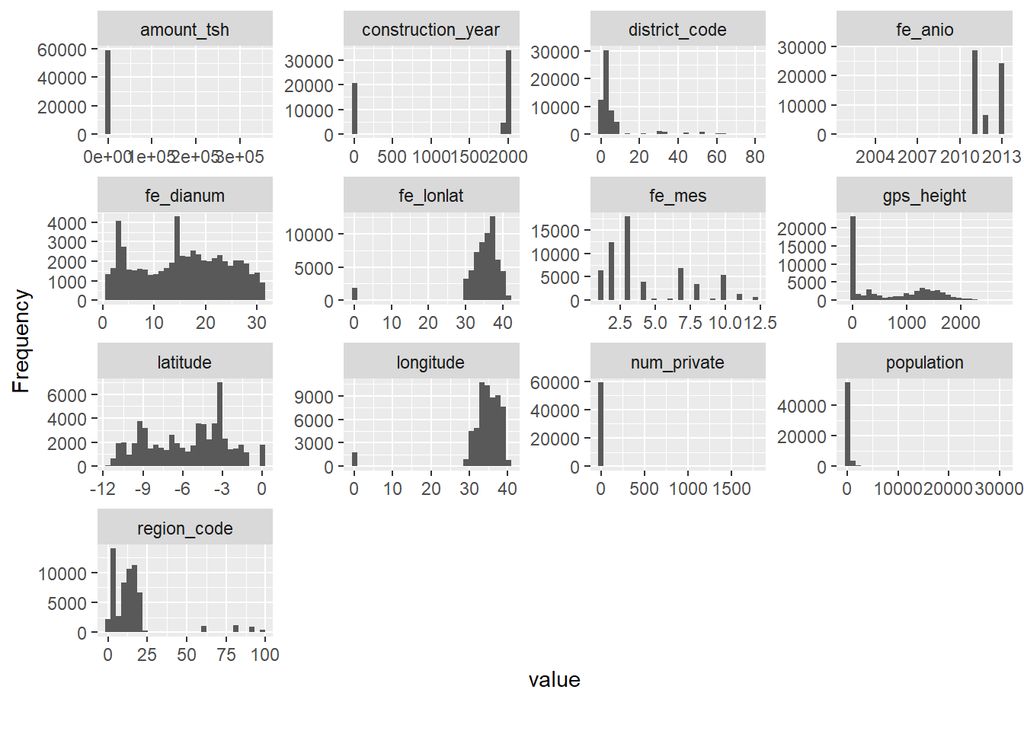

```r
# Histograma de las variables

plot_histogram(datostrain)
```

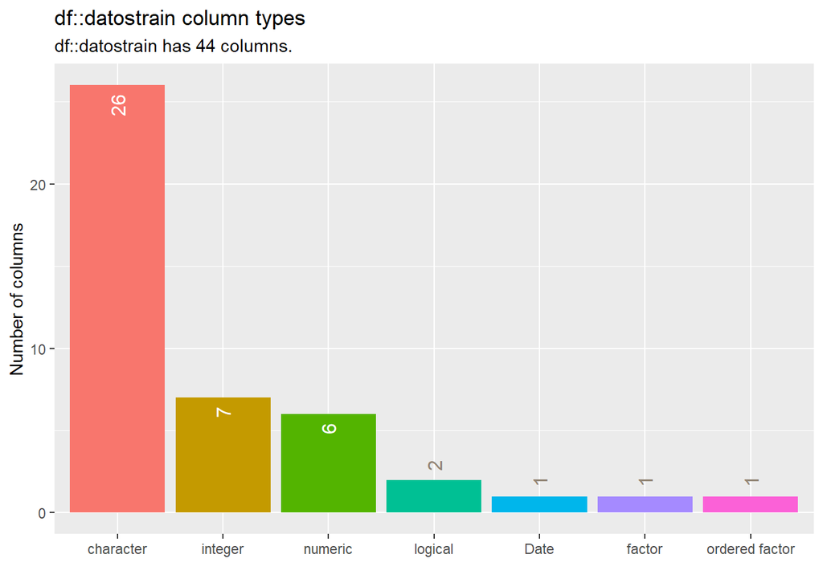

```r
# Gráfico de tipo de columnas

x <- inspect_types(datostrain)
show_plot(x)
```

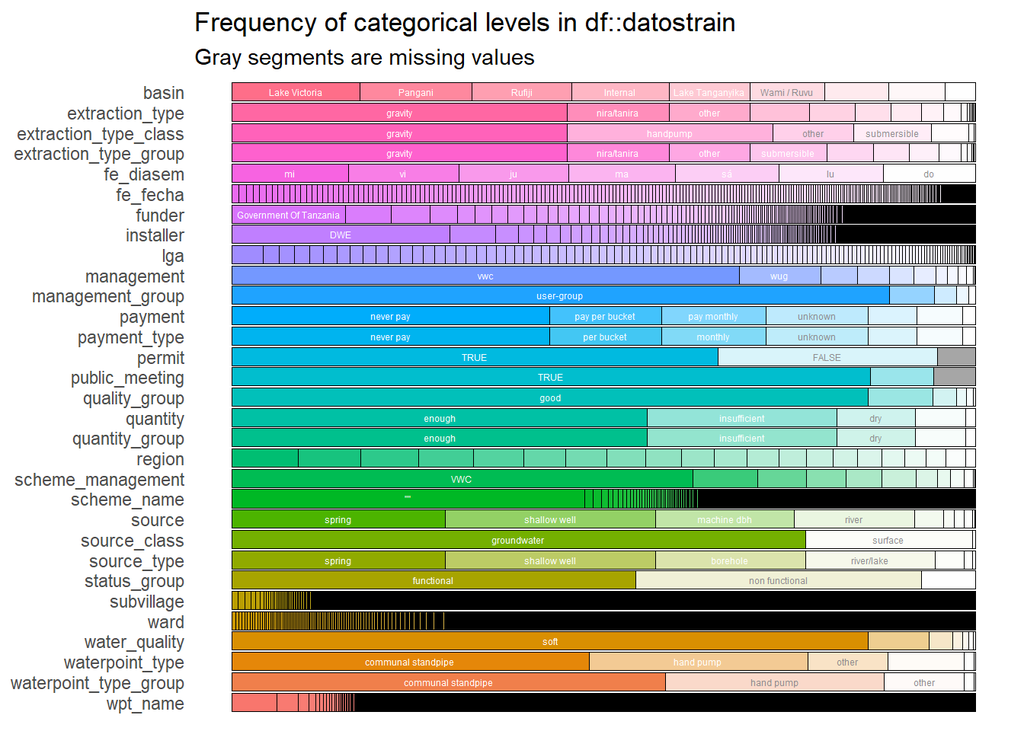

```r
# Gfáfico de variables categóricas

x <- inspect_cat(datostrain)
show_plot(x)
```

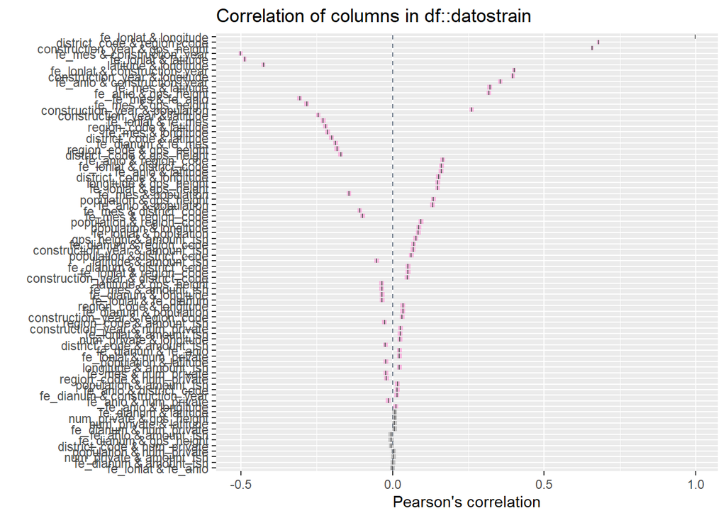

```r
# Gráfico de correlación entre columnas numericas

x <- inspect_cor(datostrain)
show_plot(x)
```

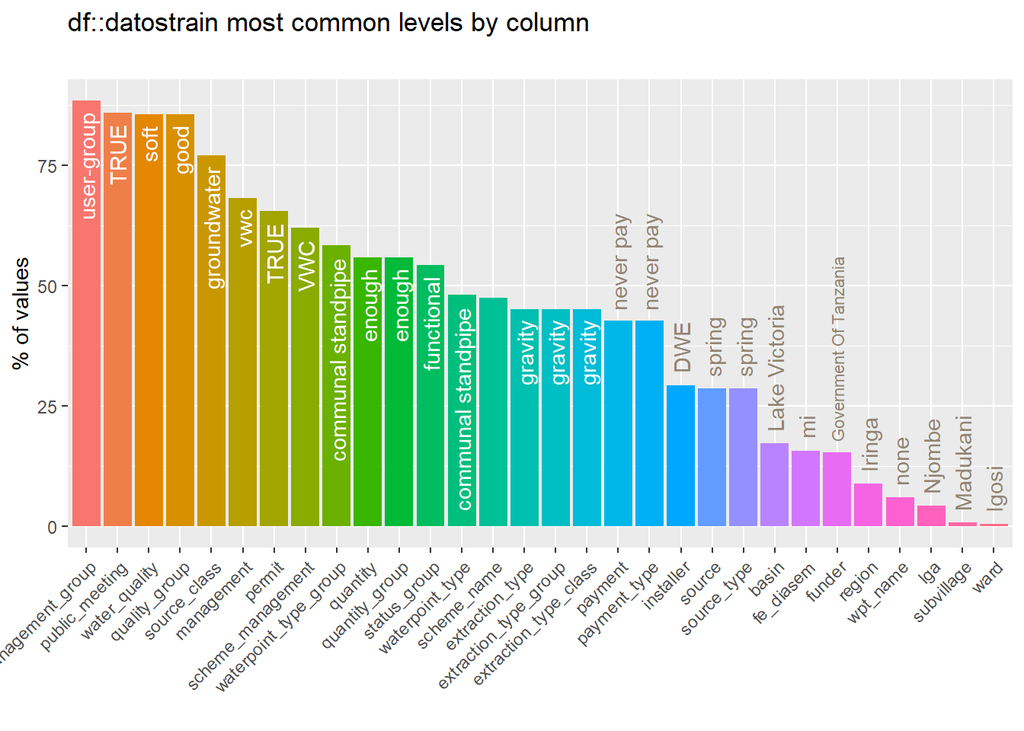

```r
# Feature imbalance bar plot

x <- inspect_imb(datostrain)
show_plot(x)
```

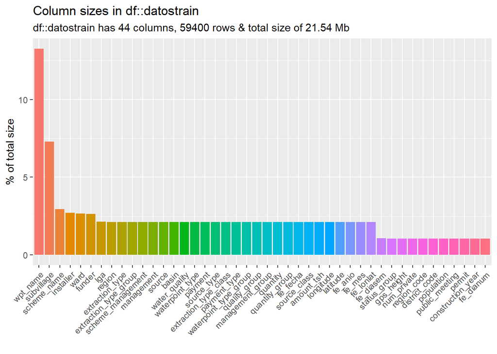

```r
# Gráfico de memoria de uso

x <- inspect_mem(datostrain)
show_plot(x)
```

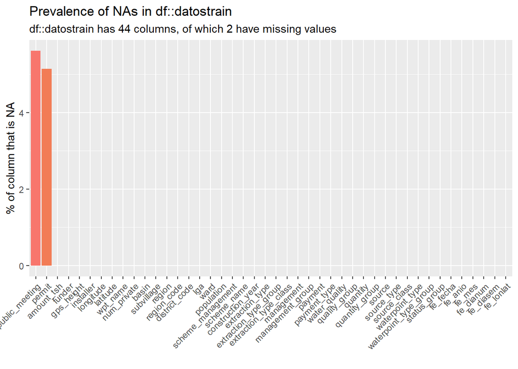

```r
# Gráfico de valores ausentes

x <- inspect_na(datostrain)
show_plot(x)
```

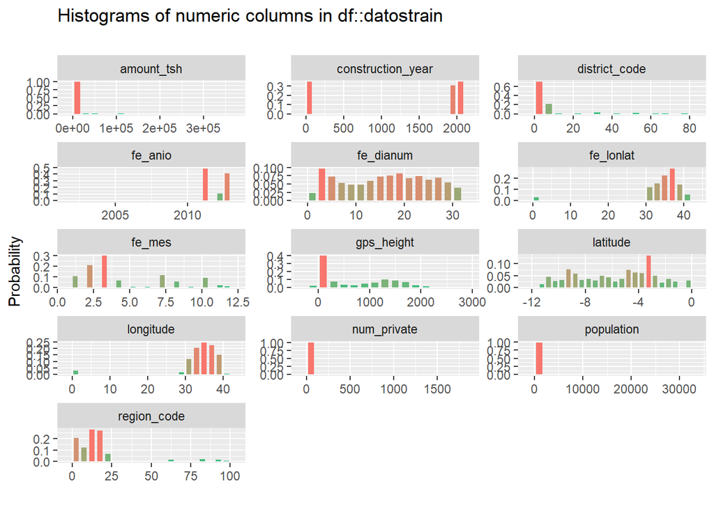

```r
# Histogramas para columnas númericas

x <- inspect_num(datostrain)
show_plot(x)
```

```r
# Balanceo de la variable objetivo

res_target <- round( prop.table(table(datostrain$status_group))*100, 2)
kable(res_target)
```

| Var1 | Freq |
| --- | --- |
| functional | 54.31 |
| functional needs repair | 7.27 |
| non functional | 38.42 |

## 4. Limpieza de datos

Del analisis anterior se pueden extraer varias conclusiones:

- Faltan algunos valores en public_meeting y permit
- Hay muchos valores 0 que deberian considerarse como NA en amount_tsh, construction_year, gps_height, num_private y population.
- La mayoria de las variables son de tipo categórico
- Hay variables categóricas que tienen demasiada cardinalidad, y tambien algunas variables son similares entre ellas y no aportan más información.
- district_code y region_code son muy similares al tener una gran correlación

Teniendo en cuenta lo anterior, procedemos a la siguiente limpieza:

```r
# Eliminamos columnas duplicadas

datostrain$payment_type <- NULL  #elimino variable payment_type por ser igual a payment
datostest$payment_type <- NULL   #elimino columna antigua de fecha

datostrain$quantity_group <- NULL  #elimino variable quantity_group por ser igual a quantity
datostest$quantity_group <- NULL   #elimino columna antigua de fecha

datostrain$extraction_type_group <- NULL  #elimino variable extraction_type_group por ser como extraction
datostest$extraction_type_group <- NULL   #elimino variable extraction_type_group por ser como extraction

datostrain$source_type <- NULL  #elimino variable extraction_type_group por ser como extraction
datostest$source_type <- NULL   #elimino variable source_type por ser como source
```

```r
# Elimino variable num_private por aportar poca información

datostrain$num_private <- NULL
datostest$num_private <- NULL

# Elimino variable quantity_group por ser igual a quantity

datostrain$quality_group <- NULL
datostest$quality_group <- NULL

# Suma de frecuencias y eliminación de variables antiguas

datostrain[ , fe_water_quality := .N , by = .(water_quality)]
datostrain$water_quality <- NULL

datostest[ , fe_water_quality := .N , by = .(water_quality)]
datostest$water_quality <- NULL


datostrain[ , fe_wpt_name := .N , by = .(wpt_name)]
datostrain$wpt_name <- NULL

datostest[ , fe_wpt_name := .N , by = .(wpt_name)]
datostest$wpt_name <- NULL


datostrain[ , fe_management_group := .N , by = .(management_group)]
datostrain$management_group <- NULL

datostest[ , fe_management_group := .N , by = .(management_group)]
datostest$management_group <- NULL


datostrain[ , fe_mes2 := .N , by = .(fe_mes)]
datostrain$fe_mes <- NULL
datostest[ , fe_mes2 := .N , by = .(fe_mes)]
datostest$fe_mes <- NULL

datostrain[ , fe_diasem2 := .N , by = .(fe_diasem)]
datostrain$fe_diasem <- NULL
datostest[ , fe_diasem2 := .N , by = .(fe_diasem)]
datostest$fe_diasem <- NULL


datostrainranger <- datostrain
datostestranger <- datostest
```

## 5. MODELO XGBOOST

Para poder aplicar el modelo XGB hay que transformar todas las variables a númericas, como se hace a continuación.

```r
#MODELO XGBOOST

#conversion a numerico de las variables

datostrain <- map_df(datostrain, function(columna) {
  columna %>%
    as.factor() %>%
    as.numeric %>%
    { . - 1 }
})

datostest <- map_df(datostest, function(columna) {
  columna %>%
    as.factor() %>%
    as.numeric %>%
    { . - 1 }
})
```

### 5.1 Testeo con nuestros datos

Para poder comprobar nuestro modelo según aplicaba cambios, primero he trabajado con mi dataset de train, particionandolo y viendo los resultados que nos arrojaba.

Este paso se puede saltar si lo que queremos es generar nuestro resultado final y definitivo.

En este punto hemos jugado con los distintos parámetros del Modelo XGB para ver los distintos valores.

Principalmente hemos modificado:

- nrounds
- max.depth

```r
#------------------------------- TRAIN -TEST - SPLIT
# Split out validation dataset
# create a list of 80% of the rows in the original dataset we can use for training

set.seed(7)
validationIndex <- createDataPartition(datostrain$status_group, p = 0.80, list = FALSE)

# select 20% of the data for validation

my_test  <- datostrain[-validationIndex,]

# use the remaining 80% of data to training and testing the

my_train <- datostrain[validationIndex,]

#Convertir a Dmatrix y quitamos la etiqueta los datos de entrenamiento

train_mat <-
  my_train %>%
  select(-status_group) %>%
  as.matrix() %>%
  xgb.DMatrix(data = ., label = my_train$status_group)

#LO MISMO CON EL DE PRUEBA

test_mat <-
  my_test %>%
  select(-status_group) %>%
  as.matrix() %>%
  xgb.DMatrix(data = ., label = my_test$status_group)

#ENTRENAMIENTO

modelo_01 <- xgboost(data = train_mat,
                     objective = "multi:softmax",
                     eval_metric = "mlogloss",
                     nrounds = 100,
                     max.depth = 6,
                     num_class = 3,
                     eta = 0.3,
                     nthread = 2,
                     early_stopping_rounds = 10)
```

```
## Will train until train_mlogloss hasn't improved in 10 rounds.
##
```

```r
#Variables de importancia
imp=xgb.importance(colnames(train_mat), model = modelo_01)
print(imp)
```

```
##                   Feature        Gain       Cover   Frequency
##  1:              quantity 0.221729352 0.069378264 0.022161298
##  2:       waterpoint_type 0.107911818 0.044258280 0.022694387
##  3:              latitude 0.056987197 0.084983911 0.093595309
##  4:             longitude 0.050542537 0.059566755 0.074023304
##  5:             fe_lonlat 0.045253231 0.058954772 0.051328916
##  6:     construction_year 0.036915109 0.043769770 0.036630874
##  7:                   lga 0.036782282 0.044115361 0.034193892
##  8:                funder 0.033563248 0.044400341 0.045769553
##  9: extraction_type_class 0.032587380 0.019518234 0.011271038
## 10:              fe_fecha 0.030273759 0.051207579 0.048358845
## 11:            gps_height 0.024952620 0.054557013 0.056659813
## 12:            amount_tsh 0.024683289 0.022256589 0.017211180
## 13:                  ward 0.024482448 0.033711171 0.055974412
## 14:            subvillage 0.023187503 0.061284501 0.076155662
```

[output cut: 22 more lines]

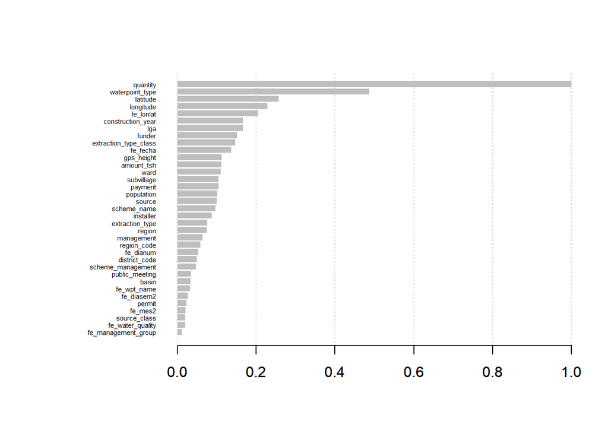

```r
#Gráfico de la importancia de las variables.
importance=xgb.importance(feature_names = colnames(train_mat),model= modelo_01)

#Gráfico de la importancia de las variables.
#Todas las Variables.
xgb.plot.importance(importance_matrix = importance,rel_to_first = T)
```

Aplicamos el modelo a nuestros datos de entrenamiento y observamos los resultados. Nos arroja una precisión del 80% por lo que sería un modelo bastante aceptable.

```r
#GENERAR PREDICCIONES
predict_01 <- predict(modelo_01, test_mat)


#EVALUACION

cbind(predict_01 , my_test$status_group) %>%
  data.frame() %>%
  table() %>%
  confusionMatrix()
```

```
## Confusion Matrix and Statistics
##
##           V2
## predict_01    0    1    2
##          0 5866  500 1083
##          1   72  222   43
##          2  509  127 3458
##
## Overall Statistics
##
##                Accuracy : 0.8035
##                  95% CI : (0.7963, 0.8106)
##     No Information Rate : 0.5427
##     P-Value [Acc > NIR] : < 2.2e-16
##
##                   Kappa : 0.6256
##
##  Mcnemar's Test P-Value : < 2.2e-16
##
## Statistics by Class:
##
##                      Class: 0 Class: 1 Class: 2
## Sensitivity            0.9099  0.26148   0.7544
## Specificity            0.7086  0.98957   0.9128
## Pos Pred Value         0.7875  0.65875   0.8447
## Neg Pred Value         0.8689  0.94568   0.8554
## Prevalence             0.5427  0.07146   0.3859
## Detection Rate         0.4938  0.01869   0.2911
## Detection Prevalence   0.6270  0.02837   0.3446
## Balanced Accuracy      0.8093  0.62553   0.8336
```

### 5.2 Modelo final

Para crear la predicción final, realizamos los mismos pasos que en el punto anterior. La diferencia es que los datos usados de test son los proporcionados por Driven Data y con ellos obtendremos la predicción para concursar.

#### 5.2.1 Resultado final

En este punto genero la predicción definitiva, y preparo el fichero que debe ser enviado.

El resultado al generarse en númerico debo convertirlo de nuevo a character para poder ser compatible con el web.

```r
#GENERAR PREDICCIONES

prediccion <- predict(modelofinal, test_mat)

#PREPARACION RESULTADOS

#resultado <- select(datostest, id)
resultado$status_group <- prediccion


resultado$status_group <- as.character(resultado$status_group)
resultado[resultado$status_group == 0, 'status_group'] = 'functional'
resultado[resultado$status_group == 1, 'status_group'] = 'functional needs repair'
resultado[resultado$status_group == 2, 'status_group'] = 'non functional'

#exportamos a csv
fwrite(resultado, file = "mi_envio.csv")
```

## 6. MODELO RANGER

```r
#Debido a que Ranger no admite NA, procedo a convertirlos en las variables permit y public_meeting

# Fix permit
datostrainranger$permit <- as.numeric(datostrainranger$permit)
datostrainranger$permit[is.na(datostrainranger$permit)] <- 2
datostrainranger$permit <- recode_factor(
  datostrainranger$permit,
  `0` = "No",
  `1` = "Yes",
  `2` = "NS",

  .default = "Should not happen"
)


# Fix public meeting
datostrainranger$public_meeting <- as.numeric(datostrainranger$public_meeting)
datostrainranger$public_meeting[is.na(datostrainranger$public_meeting)] <- 2
datostrainranger$public_meeting <- recode_factor(
  datostrainranger$public_meeting,
  `0` = "No",
  `1` = "Yes",
  `2` = "NS",
  .default = "Should not happen"
)

datostestranger$permit <- as.numeric(datostestranger$permit)
datostestranger$permit[is.na(datostestranger$permit)] <- 2
datostestranger$permit <- recode_factor(
  datostestranger$permit,
  `0` = "No",
  `1` = "Yes",
  `2` = "NS",

  .default = "Should not happen"
)


# Fix public meeting
datostestranger$public_meeting <- as.numeric(datostestranger$public_meeting)
datostestranger$public_meeting[is.na(datostestranger$public_meeting)] <- 2
datostestranger$public_meeting <- recode_factor(
  datostestranger$public_meeting,
  `0` = "No",
  `1` = "Yes",
  `2` = "NS",
  .default = "Should not happen"
)
```

```r
fit <- ranger(
              status_group ~. ,
              data = datostrainranger,
              num.trees = 500,
              importance = 'impurity',
              write.forest = TRUE,
              min.node.size = 1,
              splitrule = "gini",
              verbose = TRUE,
              classification = TRUE
            )
valor_pred <- predict(fit, data = datostestranger)
```

```r
#PREPARACION RESULTADOS

#resultado <- select(datostest, id)
resultado$status_group <- valor_pred$predictions
fwrite(resultado, file = "mi_envia.csv")
```

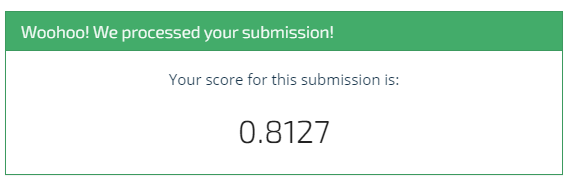

Resultado con Ranger

## 7. Otros intentos para mejorar los datos

#### Normalización de datos númericos

Para intentar solucionar el problema de falta de datos en las variables númericas, apliqué el código siguiente, consistente en intentar normalizar los datos mediante dos metodos:

- 1º aplicando K nearest neighbors
- 2º imputando la media

El resultado no fué el esperado, pero es un proceso que puede ser muy útil según los datos que tengamos. Ademas en el proceso se puede visualizar en gráficas la modificación realizada, según cada método.

**NO EJECUTABLE ACTUALMENTE

```r
datostrain %>%
   select_if(is.numeric) %>%
   gather(metric, value) %>%
   ggplot(aes(value, fill = metric)) +
   geom_density(show.legend = FALSE) +
   facet_wrap( ~ metric, scales = "free")

# using k nearest neighbors
pp_knn <- preProcess(datostrain, method = c("knnImpute", "YeoJohnson", "nzv"))
# simple output
pp_knn
# more verbose
pp_knn$method

# using medians
pp_median <- preProcess(datostrain, method = c("medianImpute", "YeoJohnson", "nzv"))
pp_median
pp_median$method

datostrain1 <- predict(pp_knn,datostrain)
datostrain2 <- predict(pp_median,datostrain)

datostrain1 %>%
  select_if(is.numeric) %>%
  gather(metric, value) %>%
  ggplot(aes(value, fill = metric)) +
      geom_density(show.legend = FALSE) +
      facet_wrap( ~ metric, scales = "free")
```

#### Valores ausentes

Para tratar los valores ausentes de permit o public_meeting, se ha intentado crear un tercer nivel con los valores ausentes agrupandandolos.

** NO EJECUTABLE EN ESTE PUNTO

```r
# Fix permit
datostrain$permit <- as.numeric(datostrain$permit)
datostrain$permit[is.na(datostrain$permit)] <- 2
datostrain$permit <- recode_factor(
  datostrain$permit,
  `0` = "No",
  `1` = "Yes",
  `2` = "NS",

  .default = "Should not happen"
)
summary(datostrain$permit)

# Fix public meeting
datostrain$public_meeting <- as.numeric(datostrain$public_meeting)
datostrain$public_meeting[is.na(datostrain$public_meeting)] <- 2
datostrain$public_meeting <- recode_factor(
  datostrain$public_meeting,
  `0` = "No",
  `1` = "Yes",
  `2` = "NS",
  .default = "Should not happen"
)
summary(datostrain$public_meeting)
```

Aprovechando el cambio realizado anteriormente en los niveles, tambien aproveché para convertir a Dummy la variable.

```r
dum_permit <- dummy_cols( datostrain, select_columns = c('permit'), remove_first_dummy = TRUE)
dim(dum_permit)
datostrain$permit <- NULL
```

#### Reducción a 10 elementos más frecuentes

Para intentar mejorar las variables categoricas he intentado aplicar una reducción a las 10 más frecuentes y el resto agruparlo en una sola.

En los casos que he probado su resultado no fué del todo satisfactorio, aunque es muy util para resumir las variables categoricas con alta cardinalidad.

** NO EJECUTABLE EN ESTE PUNTO

```r
head(freq(datostrain$basin ), 10)
basin_freq = freq(datostrain$basin, plot = F)
datostrain$basin2=ifelse(datostrain$basin %in% basin_freq[1:10,'var'], datostrain$basin, 'other')
freq(datostrain$basin2)
datostrain$basin <- NULL
```

#### Ejemplos de limpieza

Estos son otros ejemplo de limpieza que utilicé, pero lo descarté por que los resultados que obtuve no fueron muy satisfactorios

** NO EJECUTABLE

```r
# 3ª limpieza

datostrain$fe_public_meeting  <- ifelse(datostrain$public_meeting == TRUE, 'Si', 'No')
datostrain$fe_public_meeting[is.na(datostrain$public_meeting)] <- "NS"
datostrain$fe_permit  <- ifelse(datostrain$permit == TRUE, 'Si', 'No')
datostrain$fe_permit[is.na(datostrain$permit)] <- "NS"
datostrain$public_meeting <- NULL   #mismo valor asi que lo elimino
datostrain$permit <- NULL   #mismo valor asi que lo elimino

datostrain[datostrain$construction_year == 0, 'construction_year'] = 1300

datostrain$fe_permit <- NULL   #mismo valor asi que lo elimino
datostrain$fe_public_meeting <- NULL   #mismo valor asi que lo elimino
datostrain$source_class <- NULL   #mismo valor asi que lo elimino
datostrain$fe_mes2 <- NULL   #mismo valor asi que lo elimino
datostrain$fe_management_group <- NULL   #mismo valor asi que lo elimino
```

Otro ejemplo más hallando las frecuencias para todas las variables

** NO EJECUTABLE

```r
# 4ª Manera todas las variables categoricas son frecuencias

datostrain[ , fe_funder := .N , by = .(funder)]
datostrain[ , fe_installer := .N , by = .(installer)]
datostrain[ , fe_wpt_name := .N , by = .(wpt_name)]
datostrain[ , fe_basin := .N , by = .(basin)]
datostrain[ , fe_subvillage := .N , by = .(subvillage)]
datostrain[ , fe_region := .N , by = .(region)]
datostrain[ , fe_lga := .N , by = .(lga)]
datostrain[ , fe_ward := .N , by = .(ward)]
datostrain[ , fe_scheme_management := .N , by = .(scheme_management)]
datostrain[ , fe_scheme_name := .N , by = .(scheme_name)]
datostrain[ , fe_extraction_type := .N , by = .(extraction_type)]
datostrain[ , fe_extraction_type_class := .N , by = .(extraction_type_class)]
datostrain[ , fe_management := .N , by = .(management)]
datostrain[ , fe_management_group := .N , by = .(management_group)]
datostrain[ , fe_payment := .N , by = .(payment)]
datostrain[ , fe_water_quality := .N , by = .(water_quality)]
datostrain[ , fe_quality_group := .N , by = .(quality_group)]
datostrain[ , fe_quantity := .N , by = .(quantity)]
datostrain[ , fe_source := .N , by = .(source)]
datostrain[ , fe_source_class := .N , by = .(source_class)]
datostrain[ , fe_waterpoint_type := .N , by = .(waterpoint_type)]
datostrain[ , fe_waterpoint_type_group := .N , by = .(waterpoint_type_group)]
datostrain[ , fe_fe_diasem := .N , by = .(fe_diasem)]
to_rem <- c('fe_fecha','funder', 'installer', 'wpt_name','basin','subvillage','region','lga','ward','scheme_management','scheme_name','extraction_type','extraction_type_class','management','management_group','payment','water_quality','quality_group','quantity','source','source_class','waterpoint_type','waterpoint_type_group','fe_diasem')
datostrain[ , (to_rem) := NULL]

datostrain[datostrain$construction_year == 0, 'construction_year'] = 1300
```